# RF Engineering: From Atomic to Cosmic Perspective

RF Engineering Teaching Notes

2026-01-30

# 1 🔬 Atomic & Quantum Level

## 1.1 Introduction to Quantum RF

### 1.1.1 What is an Atom?

**Precise Definition:**

An atom is a quantum-electrodynamic bound system consisting of:

1. **Nucleus** (~99.94% of atomic mass, ~10⁻¹⁵ m scale)
   - **Protons**: Charge +e, mass 938.27 MeV/c²
   - **Neutrons**: Charge 0, mass 939.57 MeV/c²
   - Bound by **strong nuclear force** (range ~1-2 fm)
2. **Electrons** (define chemistry and electrical behavior, ~10⁻¹⁰ m scale)
   - Charge -e = -1.602×10⁻¹⁹ C
   - Mass 0.511 MeV/c² (1/1836 of proton)
   - Exist in **quantized states**, not classical orbits

**RF Engineering Perspective:**

From an electromagnetic viewpoint, an atom is a quantized electric dipole system with:

- Nonlinear response
- Saturation effects
- Frequency-selective absorption/emission
- Transition frequencies from RF/microwave through X-ray

### 1.1.2 Atomic Structure and Quantum States

**Electron Configuration:**

Electrons occupy orbitals defined by quantum numbers:

| Quantum Number | Symbol | Meaning | RF Analogy |
| --- | --- | --- | --- |
| Principal | n | Energy level | Mode index |
| Orbital | l | Angular momentum | Field distribution |
| Magnetic | m_l | Orientation | Mode polarization |
| Spin | m_s | Intrinsic angular momentum | ±½ |

**Key Point**: Each orbital holds maximum 2 electrons (Pauli Exclusion Principle)

### 1.1.3 Electromagnetic Wave Generation

At the quantum level, electromagnetic waves are generated through:

1. **Electronic Transitions**: Electrons moving between quantized energy levels
2. **Accelerating Charges**: Create EM fields via Maxwell’s equations
3. **Quantum Coherence**: Phase relationships in quantum systems
4. **Atomic Resonances**: Hyperfine transitions (e.g., Cs-133 at 9.19 GHz)

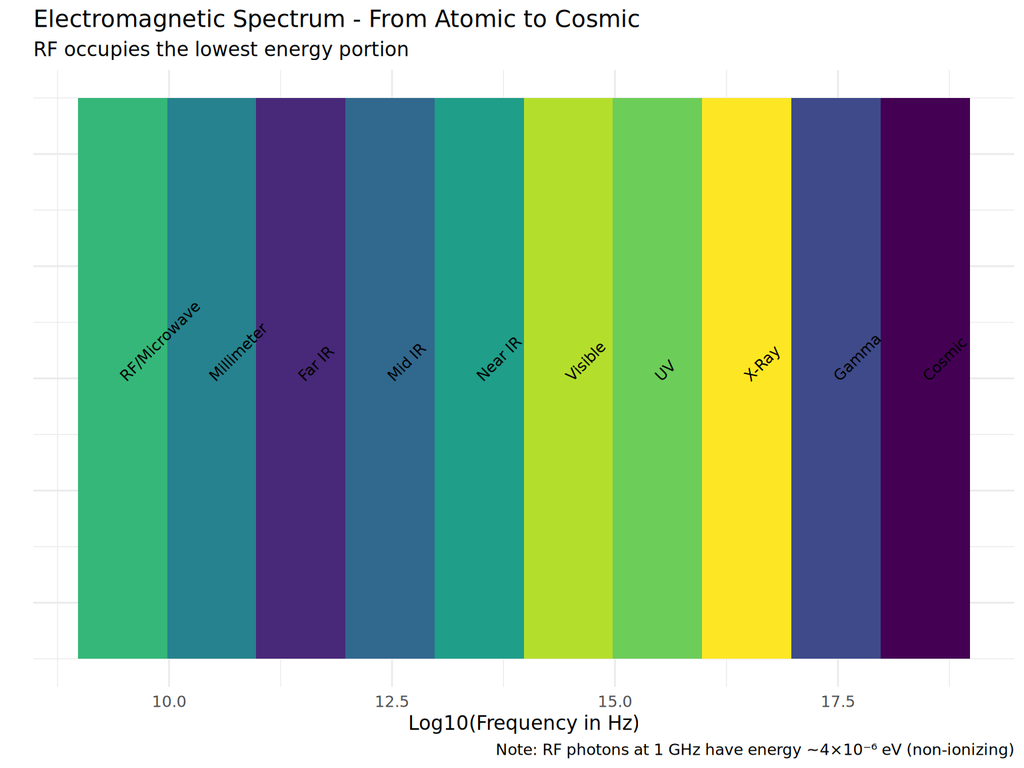

RF Spectrum Position in Electromagnetic Spectrum

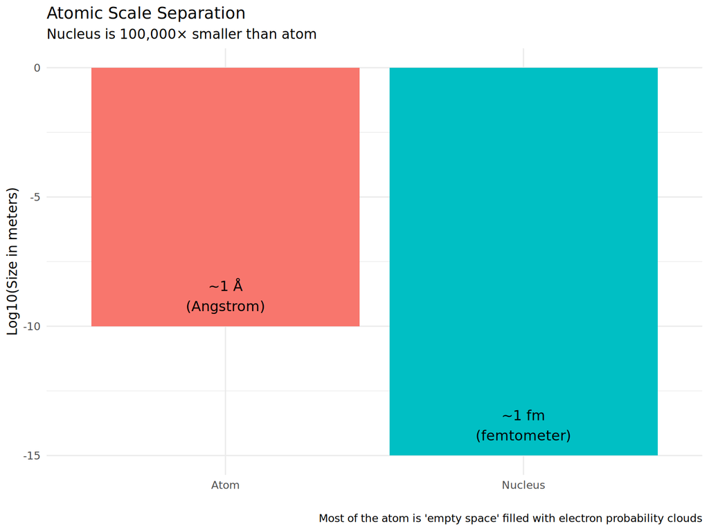

Atomic Scale and Nucleus Comparison

## 1.2 Quantum Properties

### 1.2.1 Wave-Particle Duality in RF

RF waves exhibit both wave and particle properties:

- **Wave Properties**: Interference, diffraction, polarization
- **Particle Properties**: Discrete energy quanta (photons)
- **Coherence**: Phase relationships critical for RF applications

### 1.2.2 Pauli Exclusion Principle (PEP)

**Precise Statement:**

No two identical fermions (electrons, protons, neutrons) can occupy the same quantum state simultaneously.

**Why It Exists:**

- Rooted in relativistic quantum field theory
- Consequence of spin-statistics theorem
- Fundamental symmetry of nature (not just an observation)

**Consequences for RF Engineering:**

1. **Atomic Structure**: Electron shells exist because of PEP
2. **Matter Has Size**: Without PEP, all electrons would collapse to lowest state
3. **Band Structure**: Foundation of semiconductor physics
4. **Conductors vs Insulators**: Fermi energy and band gaps
5. **Degeneracy Pressure**: Prevents stellar collapse (white dwarfs, neutron stars)

**Critical Insight:**

The Pauli Exclusion Principle is why:

- Matter doesn’t collapse
- Chemistry exists
- Semiconductors work
- Your power amplifier has a defined structure

Without PEP: No solid matter, no circuits, no RF engineering.

#### 1.2.2.1 Fermionic Spin

**What Spin Is NOT:**

- ❌ Not literal rotation
- ❌ Not classical angular momentum

**What Spin IS:**

- Intrinsic quantum degree of freedom
- For fermions: spin = ½ (in units of ℏ)
- Requires 720° rotation to return to same quantum state
- Determines particle statistics and behavior

**Why Spin Matters:**

- Couples to magnetic fields
- Determines fermion vs boson behavior
- Responsible for magnetism and band structure
- Critical for stability of matter

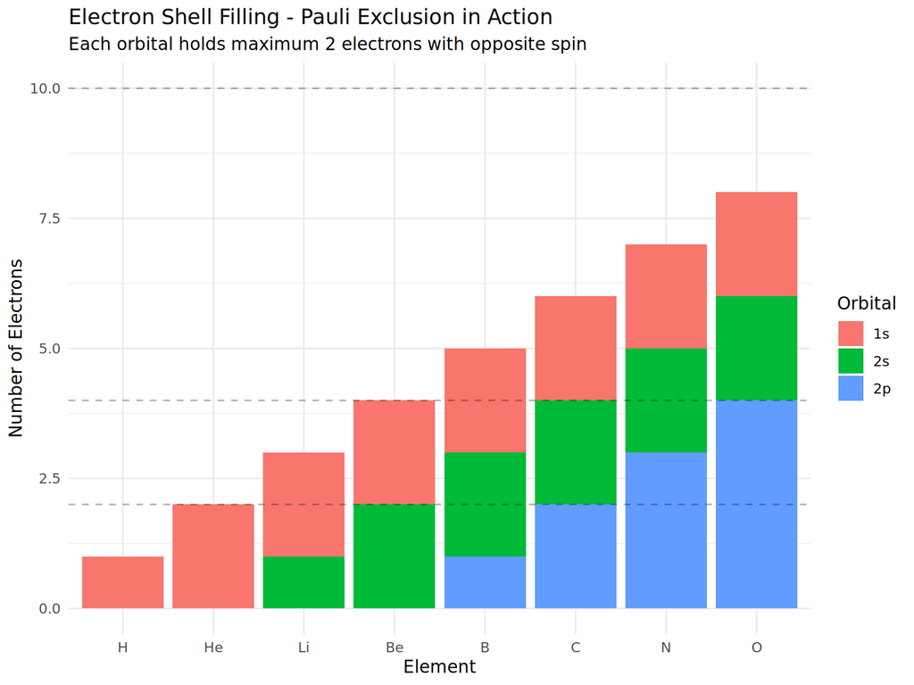

Electron Shell Filling via Pauli Exclusion

#### 1.2.2.2 Energy Levels and Transitions

**Bohr Model Application:**

For hydrogen atom:
$$E_n = -\frac{13.6
\text{ eV}}{n^2}$$

**RF Photon Energy:**

At 1 GHz:
$$E = h\nu = (6.626 \times
10^{-34})(10^9) = 6.626 \times 10^{-25} \text{ J} \approx 4.14 \times
10^{-6} \text{ eV}$$

This extremely low energy explains why RF is non-ionizing radiation.

**Energy Scale Comparison:**

- **RF (1 GHz)**: 4×10⁻⁶ eV
- **Visible Light**: 2-3 eV
- **X-rays**: keV range
- **Ionization Energy (Hydrogen)**: 13.6 eV

RF photons cannot ionize atoms - they lack sufficient energy.

## 1.3 Atomic Interactions

#### 1.3.0.1 RF Interaction with Atoms

**Key Mechanisms:**

1. **Resonant Absorption**: Atoms absorb RF at specific frequencies
2. **Stimulated Emission**: Foundation for masers (microwave amplification)
3. **Magnetic Resonance**: Nuclear and electron spin interactions

#### 1.3.0.2 Fundamental Forces

**The Four Fundamental Forces:**

| Force | Acts On | Mediator | Range | Relative Strength | Role |
| --- | --- | --- | --- | --- | --- |
| **Strong** | Quarks (color charge) | Gluons | ~1 fm | 1 | Nuclear binding |
| **Electromagnetic** | Electric charge | Photons | Infinite | 10⁻² | Atoms, chemistry, RF |
| **Weak** | Weak isospin | W/Z bosons | ~10⁻¹⁸ m | 10⁻⁶ | Beta decay |
| **Gravity** | Mass-energy | Graviton? | Infinite | 10⁻³⁹ | Cosmic structure |

**Why Gravity is Weak at Atomic Scale:**

Gravity couples to mass-energy extremely weakly compared to charge:

At atomic scales: - EM force dominates completely - Gravity is negligible - Can be safely ignored

**Is Gravity a Quantum Field?**

Current status: Unknown

- EM, weak, strong: Successfully quantized
- Gravity: Currently described by General Relativity (classical)
- Attempts: String theory, loop quantum gravity, gravitons
- No experimental confirmation yet

#### 1.3.0.3 Quantum Fields

**What is a Quantum Field?**

At the deepest level, reality consists of quantum fields. Particles are excitations of these fields.

**Known Quantum Fields (Standard Model):**

1. **Electron Field**: Excitations = electrons
2. **Quark Fields**: Up, down, strange, charm, top, bottom
   - Come in “colors”: red, green, blue (not visual colors)
   - Never exist in isolation (confinement)
   - Combine to form protons (uud) and neutrons (udd)
3. **Gluon Field**: Strong force mediator
4. **Photon Field**: Electromagnetic force (RF lives here!)
5. **W/Z Fields**: Weak force mediators
6. **Higgs Field**: Gives mass to particles

**Evidence for Fields:**

- Particle accelerators (LHC discovered Higgs boson in 2012)
- Scattering experiments
- Decay rates
- QED precision tests (accurate to 12 decimal places!)

#### 1.3.0.4 Coulomb Force and Charge

**Coulomb Repulsion:**

The electromagnetic repulsive force between like charges:

$$F = k\frac{q_1 q_2}{r^2}$$

- Like charges → repulsion
- Opposite charges → attraction

**Role in Nuclei:**

- Protons repel each other (Coulomb repulsion)
- Strong force overcomes this at short distances (~1 fm)
- Balance determines nuclear stability

#### 1.3.0.5 Why EM Fields Exist

**Electric Field:**

An electric field exists because charge is a source term in Maxwell’s equations:

$$\nabla \cdot \vec{E} =
\frac{\rho}{\epsilon_0}$$

An electron: - Is a point excitation of the electron field - Couples to the electromagnetic field - Generates an electric field (no deeper mechanism - this is fundamental)

**Magnetic Field:**

Magnetic fields arise because: - Moving charge = current - Relativity couples electricity and magnetism

**Critical Insight:**

In one reference frame you see an electric field. In a moving frame, you see a magnetic field.

Magnetism is essentially **relativistic electricity**.

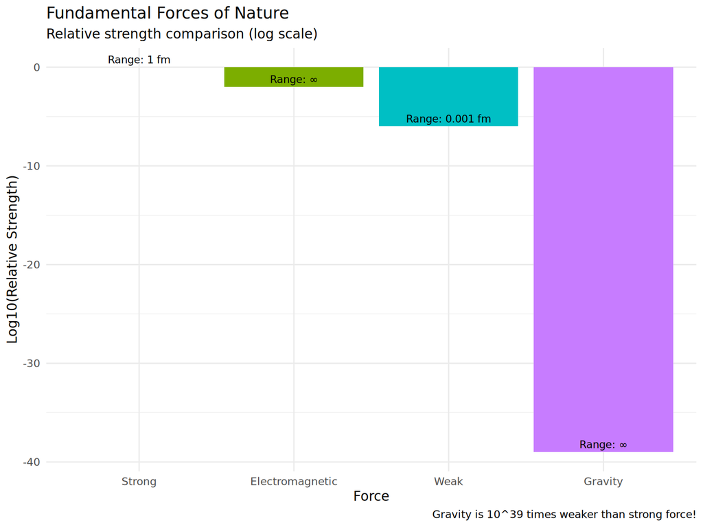

Fundamental Forces - Relative Strengths

#### 1.3.0.6 Applications

- **Atomic Clocks**: Using cesium-133 hyperfine transitions (9.192 GHz)
- **Quantum Computing**: Superconducting qubits operate at microwave frequencies
- **Magnetic Resonance Imaging (MRI)**: RF pulses interact with hydrogen nuclei
- **Masers**: Microwave amplification by stimulated emission

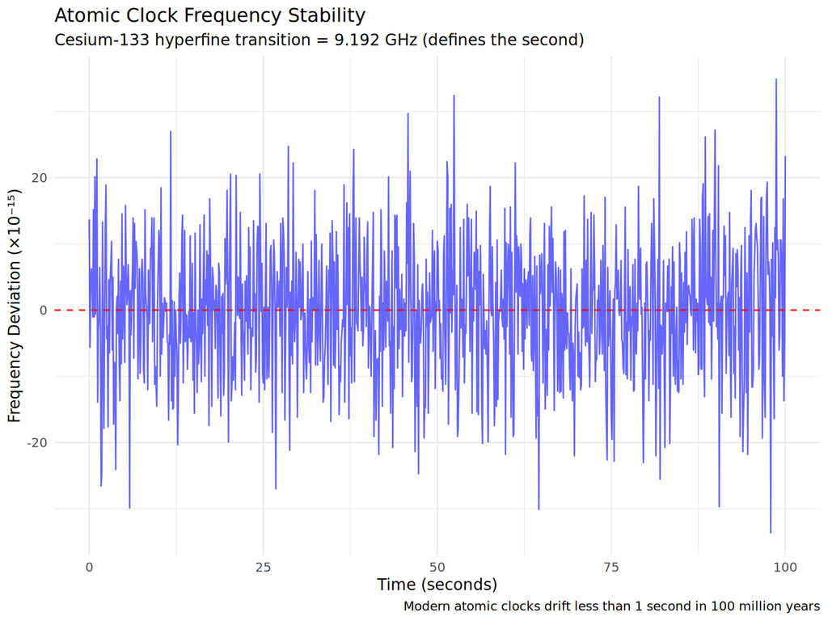

Atomic Clock Frequency Standard

## 1.4 References & Resources

#### 1.4.0.1 Key References

For further reading on quantum aspects of RF:

- Pozar, D. M. (2011). *Microwave Engineering*. 4th Edition
- Griffiths, D. J. (2017). *Introduction to Quantum Mechanics*
- Feynman, R. P. (1985). *QED: The Strange Theory of Light and Matter*

#### 1.4.0.2 Online Resources

- NIST Atomic Clock Resources
- IEEE Quantum Electronics publications
- MIT OpenCourseWare: Electromagnetic Theory

# 2 🧬 Molecular & Material Level

## 2.1 Material Properties

### 2.1.1 RF Materials Science

Understanding materials at the molecular level is crucial for RF engineering:

**Dielectric Materials:**

- Permittivity: $\epsilon = \epsilon_0 \epsilon_r$
- Loss tangent: $\tan\delta = \frac{\epsilon''}{\epsilon'}$
- Polarization mechanisms

**Magnetic Materials:**

- Permeability: $\mu = \mu_0 \mu_r$
- Ferrites for RF applications
- Magnetic losses at high frequencies

### 2.1.2 Band Structure (Foundation of Semiconductors)

**What is Band Structure?**

When atoms form a solid:

1. Atomic electron orbitals overlap
2. Discrete energy levels broaden into continuous bands
3. Two critical bands emerge:
   - **Valence Band**: Highest occupied states
   - **Conduction Band**: Lowest empty states

**The Band Gap:**

The energy difference between valence and conduction bands determines material type:

| Material Type | Band Gap | Electron Behavior | Examples |
| --- | --- | --- | --- |
| **Conductor** | No gap (overlap) | Free electrons | Cu, Au, Al |
| **Semiconductor** | Small gap (0.5-3 eV) | Thermally excited | Si, GaAs, GaN |
| **Insulator** | Large gap (>4 eV) | No conduction | SiO₂, Al₂O₃ |

**Why Band Structure Matters for RF:**

- Determines conductivity
- Controls RF losses
- Enables semiconductor devices (transistors, diodes)
- Foundation of solid-state RF electronics

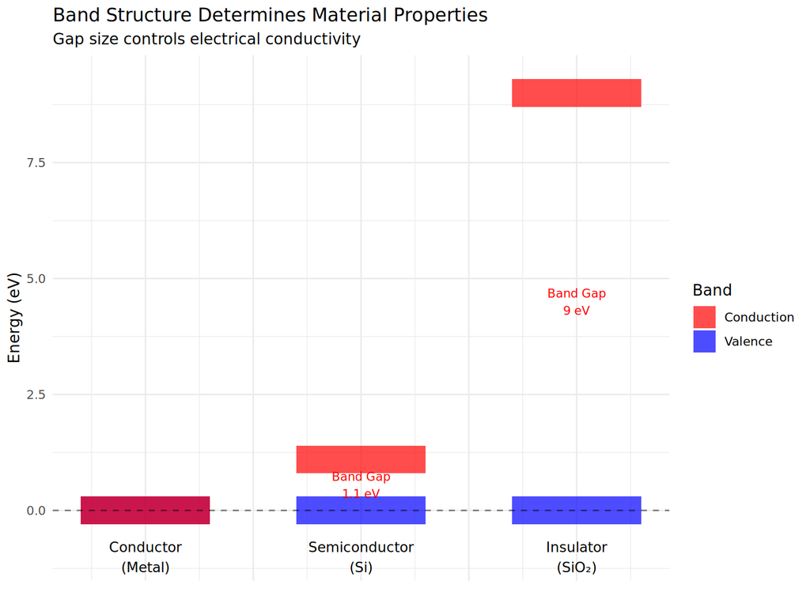

Band Structure Comparison

#### 2.1.2.1 Quasiparticles: Phonons, Plasmons, and Magnons

These are **emergent collective excitations** - not fundamental particles, but useful concepts for understanding material behavior.

**1. Phonons (Quantized Lattice Vibrations)**

- Collective motion of atoms in a crystal lattice
- Carry thermal energy
- Cause electron scattering

**Impact on RF:**

- Thermal conductivity
- Phase noise in oscillators
- Temperature-dependent losses
- Limit device performance

**2. Plasmons (Quantized Electron Density Oscillations)**

- Collective oscillation of free electron gas
- Important in metals at optical/RF frequencies
- Can have very high frequencies

**RF Applications:**

- Surface plasmon resonance
- Metamaterials
- Plasmonic antennas
- Novel RF devices

**3. Magnons (Quantized Spin Waves)**

- Collective excitation of electron spins
- Propagate in magnetic materials
- Important for ferrites

**RF Applications:**

- Magnetic materials in circulators
- Isolators
- Filters
- Spintronics (emerging field)

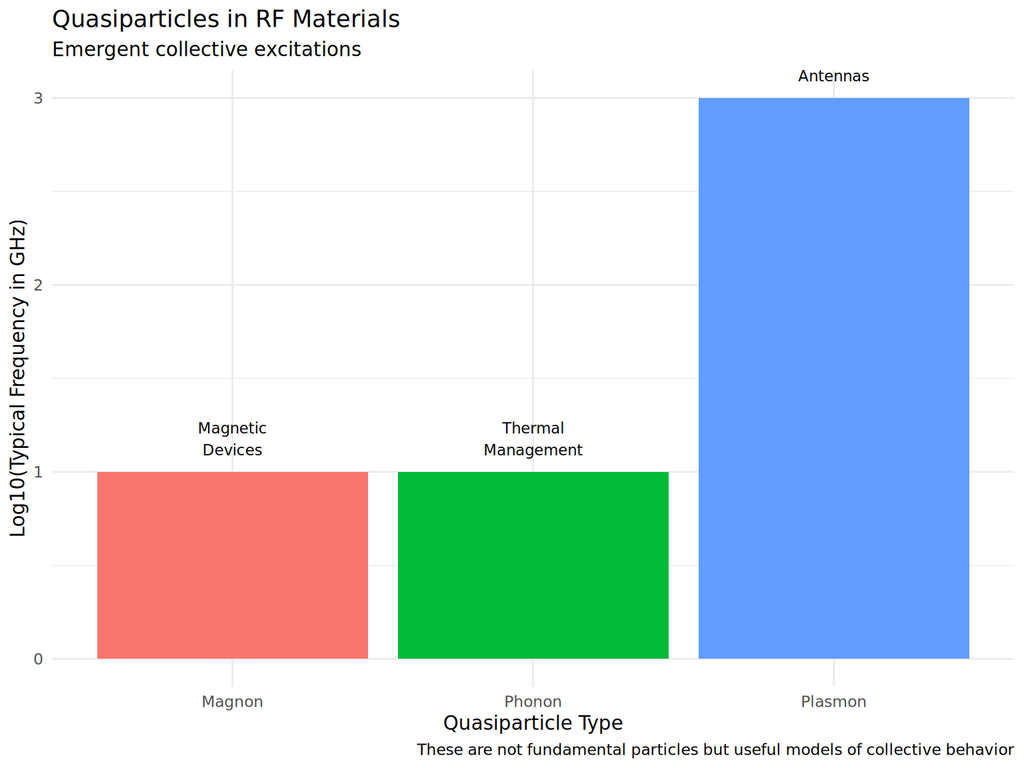

Quasiparticles in Condensed Matter

#### 2.1.2.2 Nuclear Fusion and Element Formation

**Can Elements be Transformed?**

**Chemically**: No - Chemical reactions only rearrange electrons - Nuclei remain unchanged - Elements retain identity

**Nuclear Level**: Yes - Nuclear fusion combines light nuclei - Nuclear fission splits heavy nuclei - Radioactive decay changes proton count

**Stellar Nucleosynthesis:**

Stars are cosmic forges creating elements:

1. **Hydrogen Fusion** (Main sequence stars)
   - 4H → He + energy
   - Powers the Sun
2. **Helium Fusion** (Red giants)
   - 3He → C (triple-alpha process)
3. **Carbon to Iron** (Massive stars)
   - Successive fusion up to Fe-56
   - Iron is most stable nucleus
4. **Beyond Iron** (Supernovae)
   - Requires energy input (endothermic)
   - Rapid neutron capture (r-process)
   - Creates heavy elements (Au, U, etc.)

**Key Insight:** Most elements in your RF circuit were forged in stars!

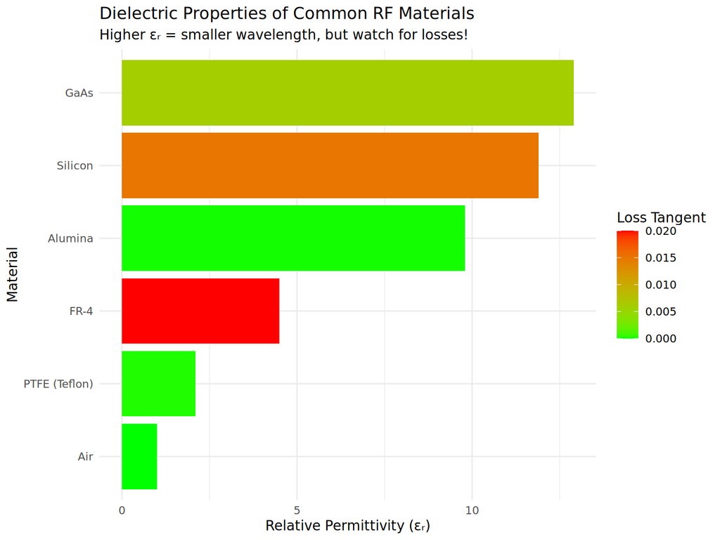

## 2.2 Substrate Materials

### 2.2.1 PCB Substrates for RF

**Common Substrates:**

1. **FR-4**: General purpose, εᵣ ≈ 4.5
   - Low cost
   - Moderate loss
   - Good for < 2 GHz
2. **Rogers Materials**: High-performance RF
   - RO4003C: εᵣ = 3.38, low loss
   - RO4350B: εᵣ = 3.48, excellent stability
   - Good for microwave frequencies
3. **PTFE-based**: Ultra-low loss
   - RT/duroid: εᵣ = 2.2-10.2
   - Excellent thermal stability

#### 2.2.1.1 Substrate Selection Criteria

Key parameters for RF substrate selection:

- Dielectric constant (εᵣ)
- Loss tangent (tan δ)
- Thermal coefficient of εᵣ
- Copper adhesion
- Cost vs. performance

## 2.3 Conductors & Semiconductors

#### 2.3.0.1 Conductor Properties and Current Flow

**What is Current? (Precise Definition)**

$$I = \frac{dQ}{dt}$$

Electric current is the **rate of flow of electric charge** through a cross-section.

**In metals:** - Charge carriers = electrons - Electrons drift under applied electric field - Drift velocity: typically mm/s to μm/s

**Critical Distinction:**

| Quantity | Speed | What It Does |
| --- | --- | --- |
| Electron drift | ~mm/s | Slow local movement |
| EM field propagation | ~c (0.6-0.9c in cable) | Fast energy transport |
| Signal velocity | ~c | Information propagates |

**The Truth About Conductors:**

1. Electrons already exist everywhere in the conductor
2. Source establishes electric field
3. Field causes local drift
4. Energy flows in the **field around the wire**, not in the wire!

**Charge vs. Electron:**

- **Charge**: A property (like mass)
- **Electron**: A particle that carries charge

**Analogy:** Current is not “cars” - it’s “traffic flow”

At high frequencies, current flows near the conductor surface:

$$\delta =
\sqrt{\frac{2}{\omega\mu\sigma}}$$

where: - δ is skin depth - ω is angular frequency - μ is permeability - σ is conductivity

**Physical Mechanism:**

- NOT electrons avoiding the center
- Fields penetrate conductors
- Induced currents oppose penetration
- Exponential decay from surface

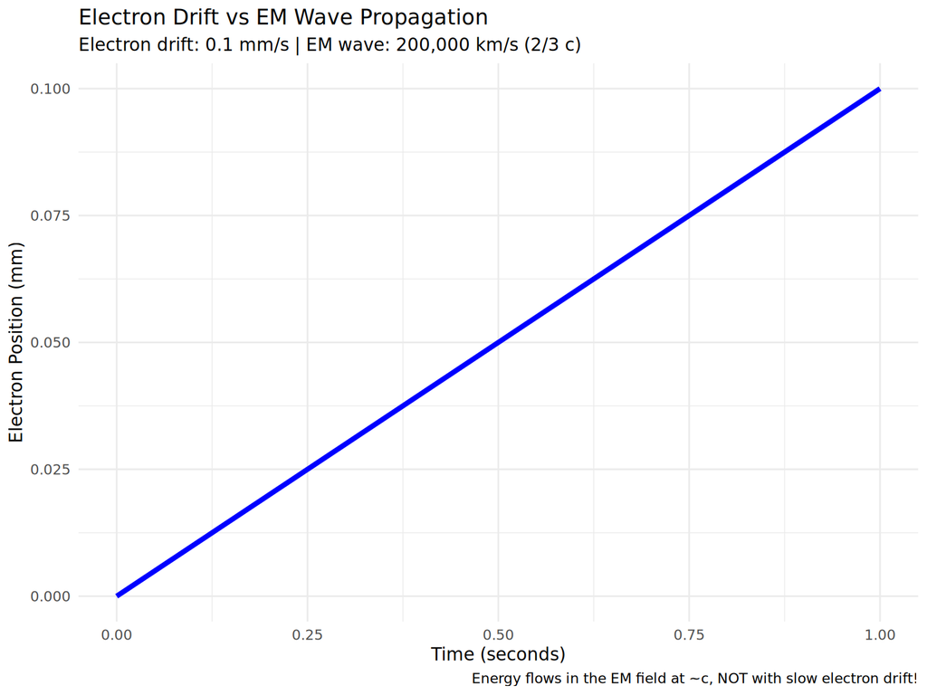

Current vs Energy Flow

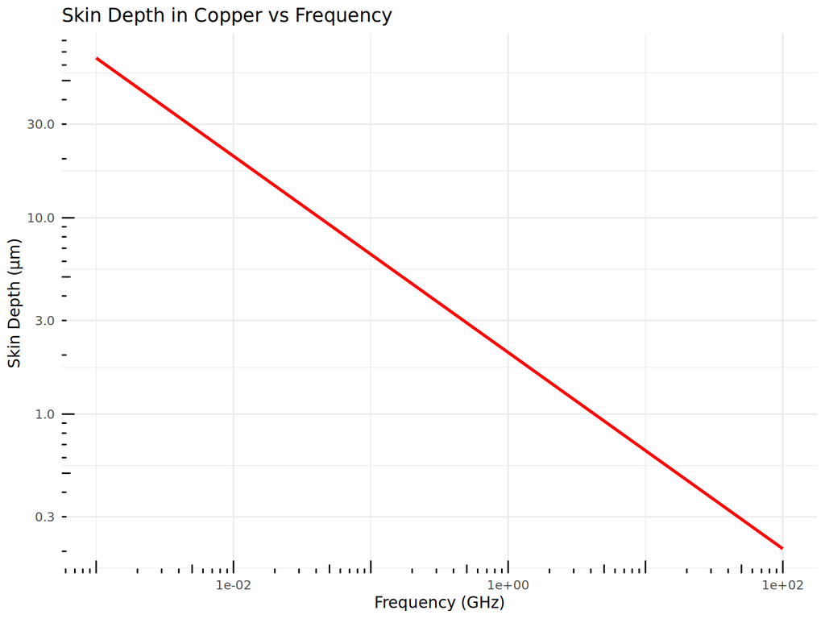

Skin Depth vs Frequency for Copper

#### 2.3.0.3 Semiconductor RF Devices

**Key Materials:**

- **Silicon (Si)**: CMOS RF circuits
- **Gallium Arsenide (GaAs)**: High-frequency amplifiers
- **Gallium Nitride (GaN)**: High-power RF
- **Silicon Germanium (SiGe)**: BiCMOS applications

## 2.4 Crystal Structures

#### 2.4.0.1 Crystalline vs Amorphous

**Impact on RF Properties:**

1. **Single Crystal**: Best performance
   - Low defects
   - Consistent properties
   - High electron mobility
2. **Polycrystalline**: Moderate performance
   - Grain boundaries
   - Variable properties
3. **Amorphous**: Lower performance
   - Disordered structure
   - Higher losses

#### 2.4.0.2 Molecular Bonding

Types of bonds affecting RF properties:

- **Covalent**: Strong, directional (semiconductors)
- **Ionic**: Strong, non-directional (ceramics)
- **Metallic**: Free electrons (conductors)
- **Van der Waals**: Weak (polymers)

# 3 💾 Device Level

## 3.1 Passive Components

### 3.1.1 RF Passive Components

**Resistors:** - Power handling - Parasitic effects at RF - Termination and matching

**Capacitors:** - Series resonant frequency (SRF) - Q factor - Temperature stability

**Inductors:** - Self-resonant frequency - Q factor - Core materials

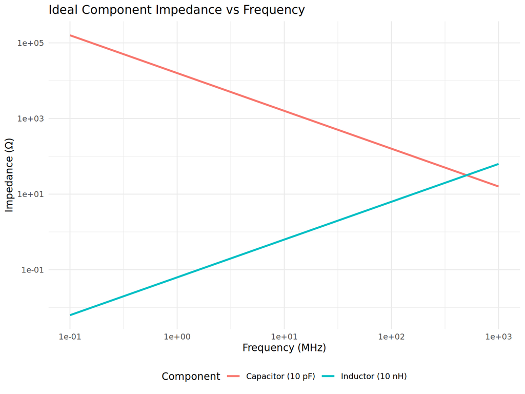

## 3.2 Active Components

#### 3.2.0.1 RF Transistors

**Types:**

1. **BJT (Bipolar Junction Transistor)**
   - Good linearity
   - Lower noise at lower frequencies
   - Current controlled
2. **FET (Field Effect Transistor)**
   - **MOSFET**: CMOS integration
   - **JFET**: Low noise
   - **HEMT**: High-frequency performance
3. **HBT (Heterojunction Bipolar Transistor)**
   - SiGe HBT
   - GaAs HBT

**Key Parameters:**

- fT (transition frequency)
- fmax (maximum oscillation frequency)
- Noise figure (NF)
- Power gain
- Linearity (IP3)

#### 3.2.0.2 RF Amplifiers

**Amplifier Classes:**

- **Class A**: Linear, inefficient (~50%)
- **Class B**: Push-pull, ~78% efficiency
- **Class AB**: Compromise
- **Class C**: High efficiency, nonlinear
- **Class E/F**: Switch-mode, very high efficiency

**Design Considerations:**

- Stability (K-factor, μ-factor)
- Matching networks (input/output)
- Bias networks
- Thermal management

## 3.3 Transmission Lines

#### 3.3.0.1 Maxwell’s Equations - The Foundation

**The Four Equations (Vacuum Form):**

1. **Gauss’s Law (Electric)**:
   $$\nabla \cdot \vec{E} =
   \frac{\rho}{\epsilon_0}$$
   *Charges create electric fields*
2. **Gauss’s Law (Magnetic)**:
   $$\nabla \cdot \vec{B} = 0$$
   *No magnetic monopoles*
3. **Faraday’s Law**:
   $$\nabla \times \vec{E} = -\frac{\partial
   \vec{B}}{\partial t}$$
   *Changing magnetic field creates electric field*
4. **Ampère-Maxwell Law**:
   $$\nabla \times \vec{B} = \mu_0 \vec{J} +
   \mu_0\epsilon_0 \frac{\partial \vec{E}}{\partial t}$$
   *Currents and changing electric fields create magnetic fields*

**Critical Insight:** The last term (Maxwell’s addition) makes EM waves possible!

#### 3.3.0.2 EM Waves from Maxwell’s Equations

**In empty space** (ρ = 0, J = 0):

Taking curl of Faraday’s law and substituting Ampère-Maxwell:

$$\nabla^2 \vec{E} = \mu_0\epsilon_0
\frac{\partial^2 \vec{E}}{\partial t^2}$$

**This is a wave equation!**

Wave speed:
$$v =
\frac{1}{\sqrt{\mu_0\epsilon_0}} = c = 3 \times 10^8 \text{
m/s}$$

**Key Facts:**

- Light is an electromagnetic wave
- No particles required
- Self-sustaining oscillation of E and B fields
- Each field creates the other

[figure not shown]

EM Wave Structure

#### 3.3.0.3 Energy and Power in EM Waves

**Energy Density:**

$$u = \frac{1}{2}\epsilon_0 E^2 +
\frac{1}{2\mu_0}B^2$$

**Poynting Vector (Energy Flow):**

$$\vec{S} = \vec{E} \times
\vec{H}$$

where $\vec{H} = \vec{B}/\mu_0$

**Critical Insight:**

👉 **Energy flows in space, not in electrons!**

**Power Flow:**

Power crossing a surface:
$$P = \int
\vec{S} \cdot d\vec{A}$$

#### 3.3.0.4 Current vs. Field - The Truth

**What Current Really Does:**

1. Source establishes electric field
2. Field rearranges surface charges
3. Fields propagate at ~c
4. Electrons respond locally (slow drift, mm/s)
5. Energy flows in field around wire

**The Wire:**

- Guides the field
- Sets boundary conditions
- Provides charge continuity

**Electrons do NOT carry energy down the wire!**

The electromagnetic field does.

#### 3.3.0.5 Why EM Waves Radiate (or Don’t)

**Radiation occurs when:**

- Charges are accelerated non-uniformly
- Current distribution changes in time and space
- Geometry allows coupling to free space (antenna)

**A straight DC wire:**

- Has EM fields (near field)
- Does NOT radiate

**An antenna:**

- Forces charge acceleration
- Launches propagating EM waves (far field)

**Key Takeaway:**

Current flow always creates EM fields. Radiation only occurs when those fields detach from conductor and propagate freely.

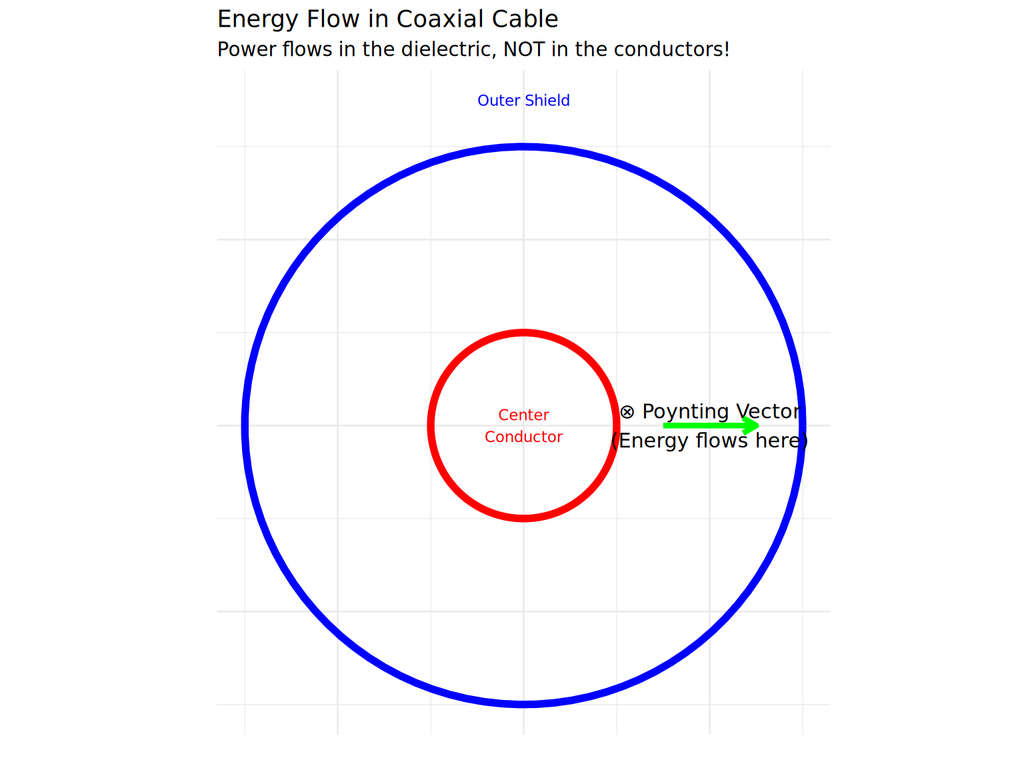

Energy Flow in Coaxial Cable

#### 3.3.0.6 Transmission Line Theory

**Fundamental Concept:**

A transmission line is a **guided electromagnetic wave structure** where conductors and dielectrics impose boundary conditions that shape how energy propagates through space.

**NOT:** “Wires with current” **IS:** “Field guiding structure”

**Characteristic Impedance:**

$$Z_0 = \sqrt{\frac{L'}{C'}} =
\sqrt{\frac{\mu}{\epsilon}} \cdot f(\text{geometry})$$

This is the **ratio of electric to magnetic field amplitudes** for a propagating mode.

- Not resistance
- Not material loss
- A field ratio

**Types:**

1. **Microstrip**: Common PCB implementation
2. **Stripline**: Symmetric, lower radiation
3. **Coaxial**: Shielded, broadband
4. **Waveguide**: High power, low loss at mm-wave

**Propagation constant:**

$$\gamma = \alpha + j\beta = \sqrt{(R +
j\omega L)(G + j\omega C)}$$

where: - α is attenuation constant - β is phase constant

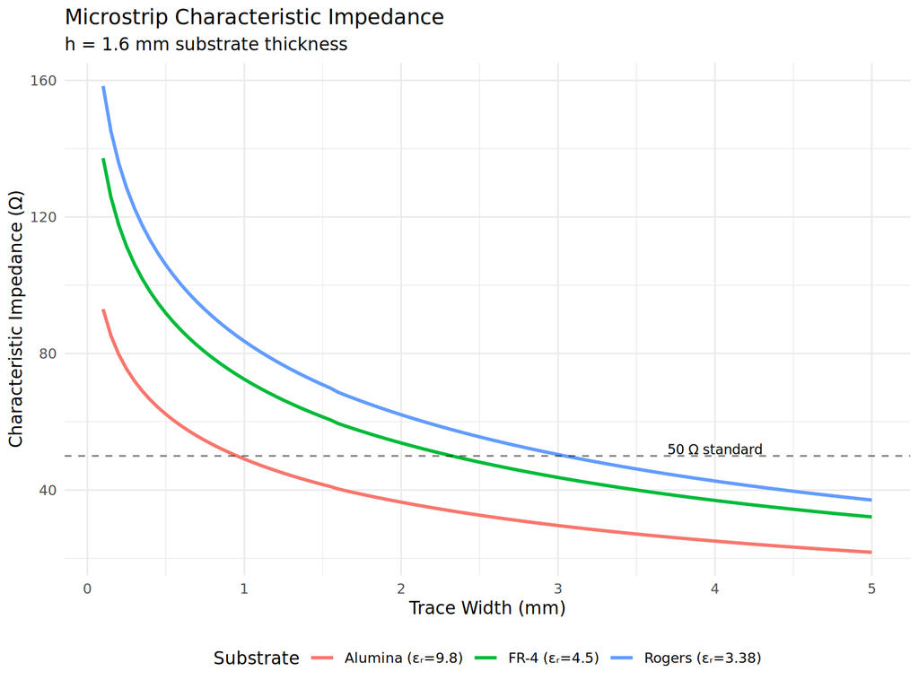

Microstrip Characteristic Impedance

#### 3.3.0.7 Why Reflections Happen

Reflections occur when **boundary conditions change** and fields cannot satisfy Maxwell’s equations smoothly.

**Load Mismatch:**

- Alters E/H ratio
- Forces part of wave to reflect
- Not electrons bouncing!

**Reflection Coefficient:**

$$\Gamma = \frac{Z_L - Z_0}{Z_L +
Z_0}$$

**Standing Wave Ratio:**

$$SWR = \frac{1 + |\Gamma|}{1 -
|\Gamma|}$$

#### 3.3.0.8 Skin Effect Reinterpreted

Skin effect is not electrons avoiding the center.

**It is:**

- Fields penetrating conductors
- Induced currents opposing penetration
- Exponential decay set by conductivity and frequency

**Skin Depth:**

$$\delta =
\sqrt{\frac{2}{\omega\mu\sigma}}$$

where: - δ is skin depth - ω is angular frequency - μ is permeability - σ is conductivity

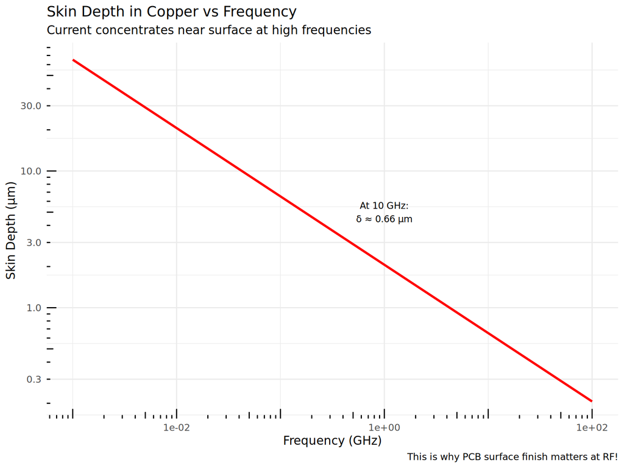

Skin Depth vs Frequency for Copper

#### 3.3.0.9 “Free Energy” Myth Destroyed

**Why perpetual/free energy is impossible:**

1. **Energy to generate EM waves comes from source** (battery, generator)
2. **Source loses energy** transferred into EM fields
3. **Conservation of energy** - fundamental law
4. **Maxwell’s equations** explicitly encode energy conservation
5. **Radiation resistance** - antennas extract energy from source

**EM waves propagate** but don’t multiply or self-sustain.

**Once launched:**

- Waves propagate
- They do NOT amplify themselves
- No feedback without external source
- Maxwell’s equations are linear (no gain mechanism)

**One sentence that ends the debate:**

An EM wave is a one-time transfer of energy from a source into the electromagnetic field, constrained by conservation laws - no configuration can create energy without paying for it at the source.

## 3.4 Antennas

#### 3.4.0.1 Antenna Fundamentals

**Key Parameters:**

- **Gain**: Directivity × Efficiency
- **Directivity**: Power concentration
- **Radiation Pattern**: Spatial distribution
- **Impedance**: Matching to feedline
- **Bandwidth**: Operating frequency range
- **Polarization**: E-field orientation

**Friis Transmission Equation:**

$$P_r = P_t G_t G_r
\left(\frac{\lambda}{4\pi d}\right)^2$$

#### 3.4.0.2 Common Antenna Types

1. **Dipole**: λ/2 length, omnidirectional
2. **Monopole**: λ/4 with ground plane
3. **Patch**: Planar, directional
4. **Horn**: Broadband, high gain
5. **Parabolic**: Very high gain
6. **Array**: Beam steering capability

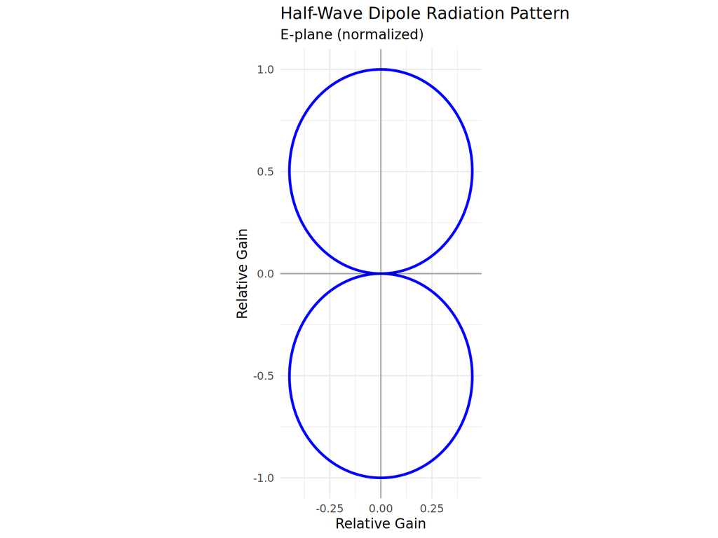

Dipole Antenna Radiation Pattern

## 3.5 Filters & Matching

#### 3.5.0.1 RF Filters

**Filter Types:**

1. **Low-Pass**: Passes DC to fc
2. **High-Pass**: Passes fc to ∞
3. **Band-Pass**: Passes f1 to f2
4. **Band-Stop**: Rejects f1 to f2

**Implementation:**

- Lumped element (L, C)
- Distributed element (transmission line)
- Cavity resonators
- SAW/BAW filters
- Ceramic filters

#### 3.5.0.2 Impedance Matching

**Why Match?**

- Maximum power transfer
- Minimize reflections
- Improve noise figure

**Matching Methods:**

1. **L-Match**: 2 elements
2. **Pi-Match**: 3 elements, more flexibility
3. **T-Match**: 3 elements
4. **Stub Matching**: Transmission line based

**Smith Chart:**

- Graphical impedance matching tool
- Plots reflection coefficient
- Facilitates matching network design

# 4 📡 System Level

## 4.1 RF Systems

### 4.1.1 Complete RF System Architecture

**Transmitter Chain:**

```
Data → Baseband → Modulator → Upconverter → PA → Filter → Antenna
```

**Receiver Chain:**

```
Antenna → Filter → LNA → Downconverter → Demodulator → Baseband → Data
```

**Key Subsystems:**

1. **Frequency Generation**: PLLs, VCOs, synthesizers
2. **Signal Processing**: Modulation/demodulation
3. **Power Amplification**: Transmit chain
4. **Low Noise Amplification**: Receive chain
5. **Filtering**: Selectivity and interference rejection

### 4.1.2 System Link Budget

**Link Budget Equation:**

$$P_{rx} = P_{tx} + G_{tx} - L_{path} -
L_{misc} + G_{rx} \text{ (in dB)}$$

**Path Loss (Free Space):**

$$L_{path} = 20\log_{10}(d) +
20\log_{10}(f) + 20\log_{10}\left(\frac{4\pi}{c}\right)$$

**Receiver Sensitivity:**

$$P_{sens} = kTB + NF +
SNR_{req}$$

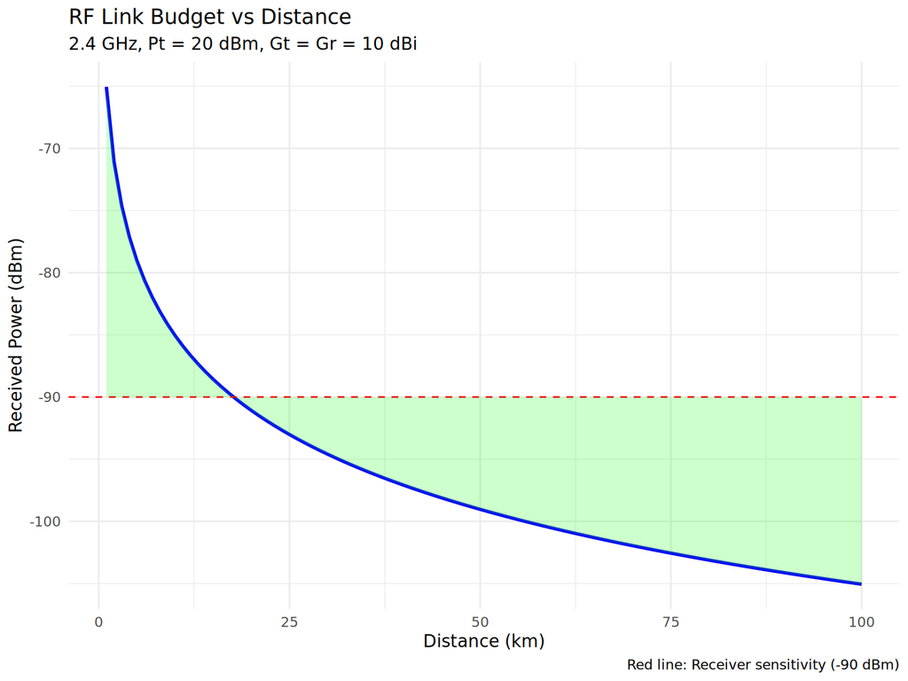

Link Budget Analysis

## 4.2 Modulation Schemes

#### 4.2.0.1 Digital Modulation

**Common Schemes:**

1. **ASK (Amplitude Shift Keying)**
   - On-Off Keying (OOK)
   - Simple, prone to noise
2. **FSK (Frequency Shift Keying)**
   - Bluetooth, LoRa
   - Better noise immunity
3. **PSK (Phase Shift Keying)**
   - BPSK: 1 bit/symbol
   - QPSK: 2 bits/symbol
   - 8PSK: 3 bits/symbol
4. **QAM (Quadrature Amplitude Modulation)**
   - 16-QAM, 64-QAM, 256-QAM
   - High spectral efficiency
   - Requires good SNR

#### 4.2.0.2 Spectral Efficiency

**Comparison:**

| Modulation | Bits/Symbol | Bandwidth Efficiency |
| --- | --- | --- |
| BPSK | 1 | 1 bit/s/Hz |
| QPSK | 2 | 2 bit/s/Hz |
| 16-QAM | 4 | 4 bit/s/Hz |
| 64-QAM | 6 | 6 bit/s/Hz |

**Trade-offs:**

- Higher order → More data rate
- Higher order → More sensitive to noise
- Higher order → More power consumption

## 4.3 Communication Standards

#### 4.3.0.1 Wireless Standards

**Cellular:**

- **2G**: GSM (900/1800 MHz)
- **3G**: UMTS/WCDMA (2.1 GHz)
- **4G**: LTE (multiple bands)
- **5G**: Sub-6 GHz and mmWave (24-100 GHz)

**WiFi (IEEE 802.11):**

- 802.11b/g/n: 2.4 GHz
- 802.11a/n/ac: 5 GHz
- 802.11ax (WiFi 6): 2.4/5 GHz
- 802.11be (WiFi 7): 2.4/5/6 GHz

**IoT:**

- **Bluetooth**: 2.4 GHz ISM band
- **Zigbee**: 2.4 GHz IEEE 802.15.4
- **LoRa**: Sub-GHz (433/868/915 MHz)
- **NB-IoT**: Licensed cellular bands

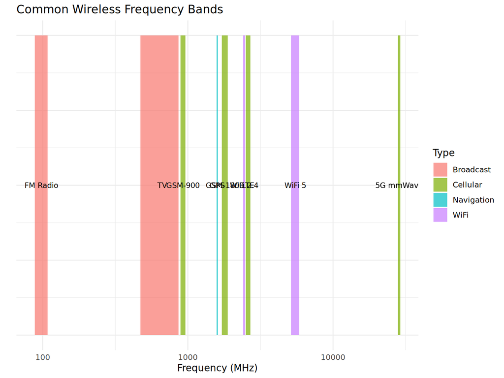

Common Wireless Bands

## 4.4 Radar Systems

#### 4.4.0.1 Radar Fundamentals

**Radar Equation:**

$$P_r = \frac{P_t G^2 \lambda^2
\sigma}{(4\pi)^3 R^4}$$

where: - Pt: Transmitted power - G: Antenna gain - λ: Wavelength - σ: Radar cross section - R: Range

**Types of Radar:**

1. **Pulse Radar**: Range measurement
2. **Doppler Radar**: Velocity measurement
3. **FMCW**: Continuous wave, range/velocity
4. **SAR**: Synthetic Aperture Radar
5. **Phased Array**: Electronic beam steering

#### 4.4.0.2 Radar Applications

**Military:** - Air defense - Target tracking - Navigation

**Civilian:** - Weather monitoring - Air traffic control - Automotive (collision avoidance) - Speed enforcement

**Range Resolution:**

$$\Delta R = \frac{c}{2B}$$

where B is the bandwidth.

## 4.5 System Performance

#### 4.5.0.1 Key Performance Metrics

**Noise Figure (NF):**

Degradation of SNR through a system:
$$NF
= 10\log_{10}\left(\frac{SNR_{in}}{SNR_{out}}\right)$$

**Cascaded Noise Figure (Friis):**

$$F_{total} = F_1 + \frac{F_2-1}{G_1} +
\frac{F_3-1}{G_1G_2} + ...$$

**Dynamic Range:**

- **Spurious-Free Dynamic Range (SFDR)**
- **Intermodulation products**: IP2, IP3
- **1-dB Compression Point**: P1dB

**Sensitivity:**

$$P_{sens} = -174 \text{ dBm/Hz} +
10\log_{10}(B) + NF + SNR_{req}$$

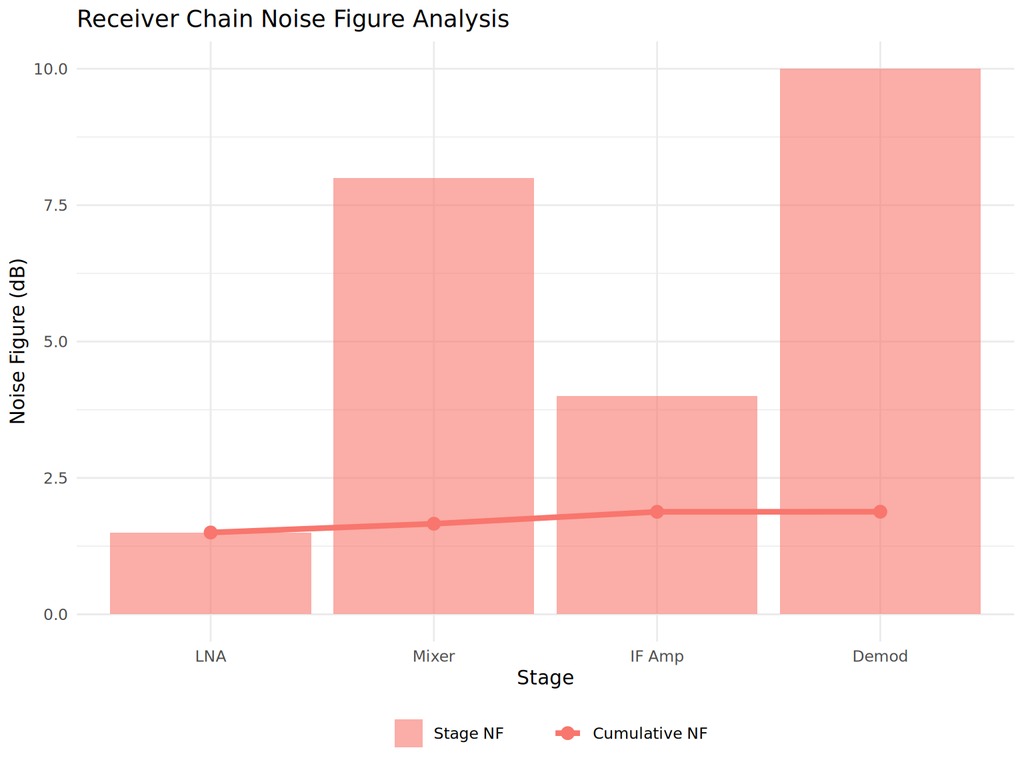

Cascaded System Noise Figure

# 5 🌍 Terrestrial Level

## 5.1 Network Infrastructure

### 5.1.1 Terrestrial RF Networks

**Cellular Network Architecture:**

1. **User Equipment (UE)**: Mobile devices
2. **Base Stations (eNodeB/gNB)**: Cell towers
3. **Backhaul**: Fiber/microwave links
4. **Core Network**: Switching and routing

**Coverage Types:**

- **Macrocells**: Large area, outdoor
- **Microcells**: Urban, hotspots
- **Picocells**: Indoor, small area
- **Femtocells**: Home, enterprise

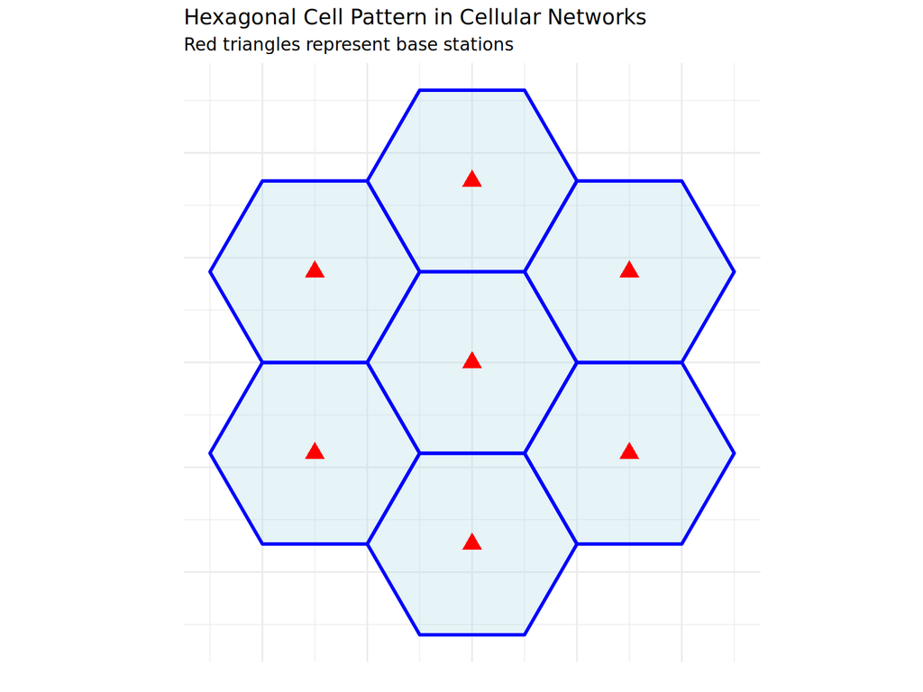

Cellular Coverage Patterns

## 5.2 Propagation Models

#### 5.2.0.1 Terrestrial Propagation

**Path Loss Models:**

1. **Free Space**: Line of sight
   $$L_{fs} = 20\log_{10}(d) + 20\log_{10}(f) + 92.45
   \text{ dB}$$
2. **Okumura-Hata**: Urban/suburban
   - Empirical model
   - 150 MHz - 1.5 GHz
   - Up to 20 km range
3. **COST-231**: Extended Hata
   - 1.5 - 2 GHz
   - Urban environments
4. **ITU Models**: Various scenarios

**Propagation Effects:**

- **Reflection**: From buildings, ground
- **Diffraction**: Over obstacles
- **Scattering**: From rough surfaces
- **Multipath**: Multiple signal paths
- **Fading**: Time-varying channel

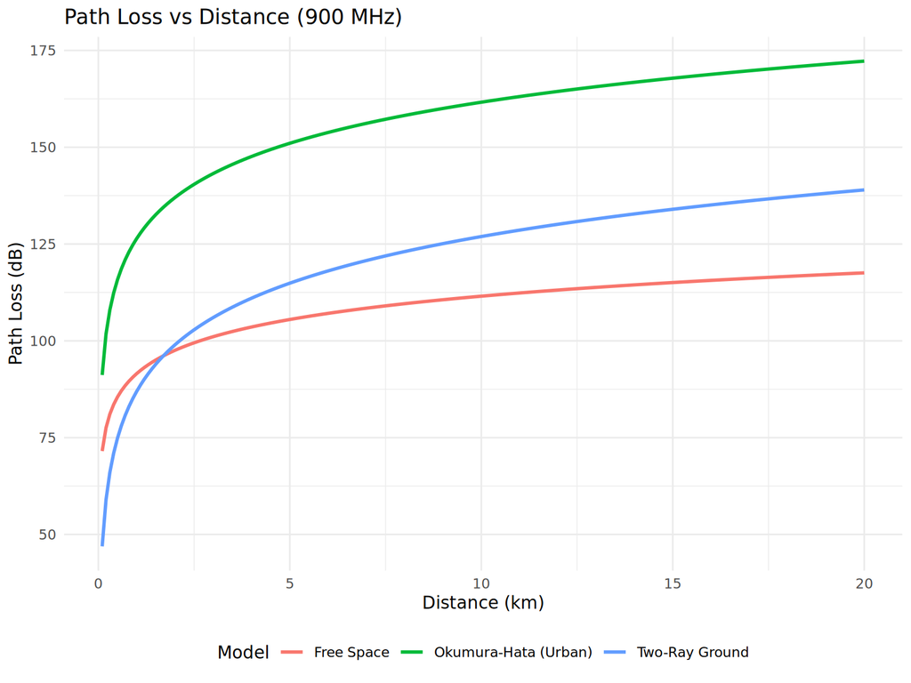

Comparison of Path Loss Models

## 5.3 Spectrum Management

#### 5.3.0.1 Frequency Allocation

**Regulatory Bodies:**

- **ITU**: International Telecommunication Union
- **FCC**: Federal Communications Commission (US)
- **ETSI**: European Telecommunications Standards Institute
- **National regulators**: Country-specific

**Spectrum Bands:**

1. **Licensed**: Exclusive use, cellular operators
2. **Unlicensed**: Shared, WiFi, Bluetooth (ISM bands)
3. **Licensed Shared**: CBRS, dynamic access

**ISM Bands (Industrial, Scientific, Medical):**

- 433 MHz (Region 1)
- 915 MHz (Region 2)
- 2.4 GHz (Global)
- 5.8 GHz (Global)

#### 5.3.0.2 Interference Management

**Co-channel Interference:**

- Same frequency, different cells
- Frequency reuse patterns

**Adjacent Channel Interference:**

- Nearby frequencies
- Filter requirements
- Spectral masks

**Intermodulation:**

- Non-linear mixing
- 3rd order products most critical

## 5.4 Backhaul & Distribution

#### 5.4.0.1 Wireless Backhaul

**Microwave Links:**

- Point-to-point
- 6-42 GHz typical
- Line of sight required
- High capacity (up to 10 Gbps)

**mmWave Backhaul:**

- E-band (71-76, 81-86 GHz)
- V-band (57-64 GHz)
- Very high capacity
- Short range (< 5 km)

**Satellite Backhaul:**

- Remote/rural areas
- Higher latency
- Expensive

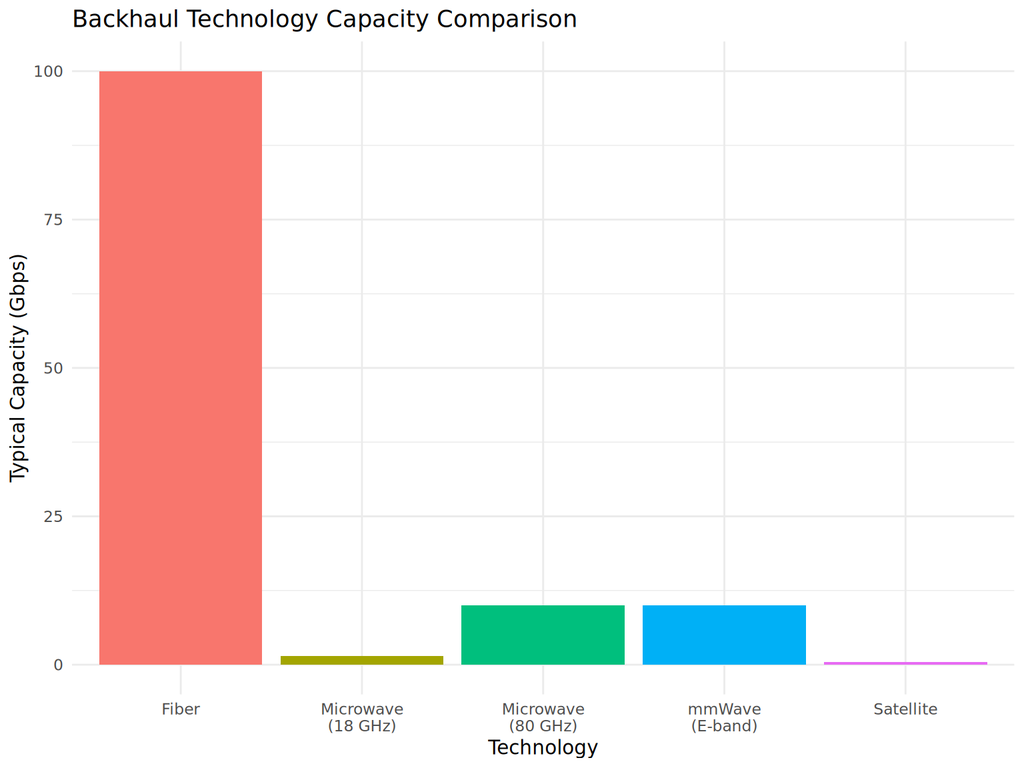

Backhaul Technology Comparison

## 5.5 Smart Cities & IoT

#### 5.5.0.1 IoT Connectivity

**LPWAN (Low Power Wide Area Networks):**

1. **LoRaWAN**:
   - Long range (2-15 km)
   - Low power
   - Unlicensed band
   - Low data rate (0.3-50 kbps)
2. **NB-IoT**:
   - Cellular infrastructure
   - Licensed spectrum
   - Better coverage
   - Higher reliability
3. **Sigfox**:
   - Ultra-narrow band
   - Very low power
   - Limited messages/day

**Applications:**

- Smart metering
- Environmental monitoring
- Asset tracking
- Smart agriculture
- Industrial IoT

#### 5.5.0.2 5G and Beyond

**5G Features:**

- **eMBB**: Enhanced Mobile Broadband (> 1 Gbps)
- **URLLC**: Ultra-Reliable Low Latency (< 1 ms)
- **mMTC**: Massive Machine Type Communications

**Technologies:**

- Massive MIMO
- Beamforming
- Network slicing
- Edge computing

# 6 🚀 Cosmic Level

## 6.1 Space Communications

### 6.1.1 Satellite Communication Systems

**Orbits:**

**Frequency Bands:**

- **L-band**: 1-2 GHz (mobile satcom)
- **S-band**: 2-4 GHz (weather, communications)
- **C-band**: 4-8 GHz (fixed satcom)
- **X-band**: 8-12 GHz (military, space)
- **Ku-band**: 12-18 GHz (broadcast, VSAT)
- **Ka-band**: 26-40 GHz (high-throughput)

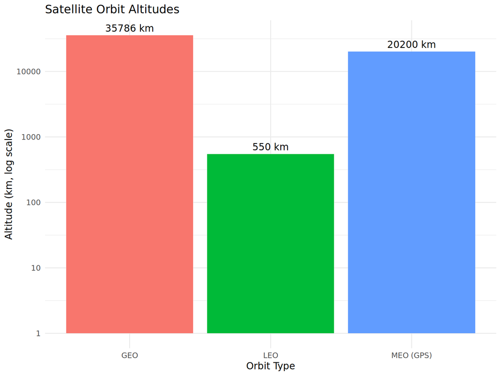

Satellite Orbit Comparison

#### 6.1.1.1 Deep Space Communications

**NASA Deep Space Network (DSN):**

- 70m parabolic antennas
- X-band (7-8 GHz) and Ka-band (32 GHz)
- Support for Mars, Jupiter, beyond

**Link Budget Challenges:**

- Enormous distances
- Very low received power (femtowatts)
- Large antennas required
- Error correction critical

**Example: Mars Communication**

At closest approach (~55 million km): - Path loss: ~310 dB at 8 GHz - One-way light time: ~3 minutes - Data rates: Few kbps to ~250 Mbps (Mars orbit)

## 6.2 Radio Astronomy

#### 6.2.0.1 Radio Telescopes

**Science Goals:**

- Study cosmic microwave background
- Observe distant galaxies
- Detect pulsars and quasars
- Search for extraterrestrial intelligence (SETI)

**Famous Instruments:**

1. **Arecibo** (collapsed 2020): 305m dish
2. **Green Bank Telescope**: 100m, steerable
3. **Very Large Array (VLA)**: 27×25m dishes
4. **ALMA**: 66 antennas, 12-7m, Chile
5. **Square Kilometre Array (SKA)**: Under construction

**Frequencies:**

- HI line: 1420 MHz (neutral hydrogen)
- OH lines: 1612, 1665, 1667, 1720 MHz
- Water maser: 22 GHz
- Wide spectral coverage for continuum

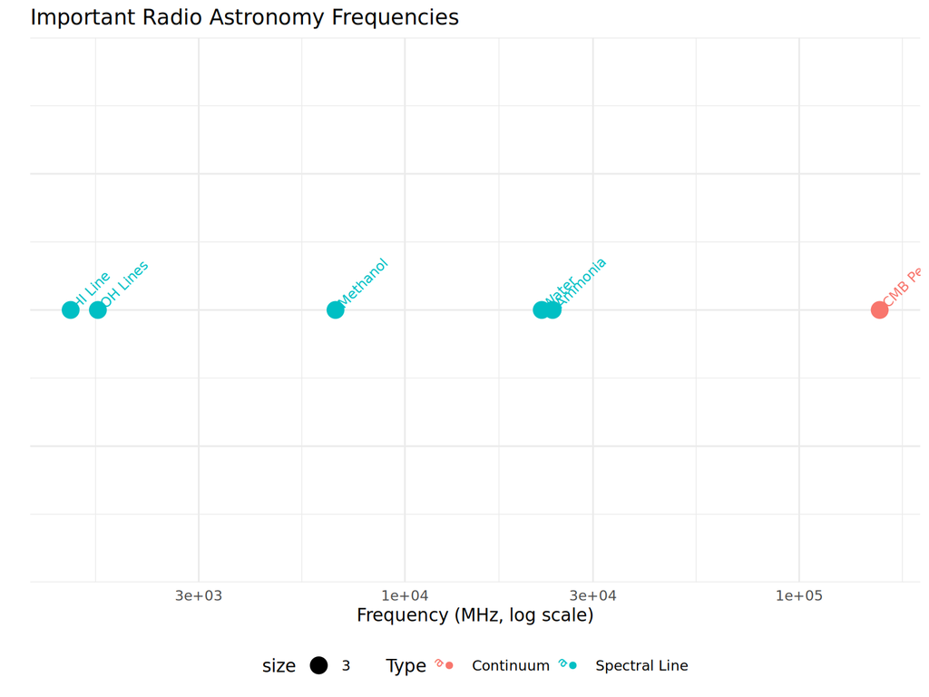

Radio Astronomy Frequency Bands

#### 6.2.0.2 Interferometry

**Principle:**

Combine signals from multiple antennas to create a virtual large aperture.

**Resolution:**

$$\theta = \frac{\lambda}{D}$$

where D is the baseline (antenna separation).

**Very Long Baseline Interferometry (VLBI):**

- Earth-scale baselines
- Extremely high resolution
- Requires precise timing (atomic clocks)
- Event Horizon Telescope (EHT)

## 6.3 Navigation Systems

#### 6.3.0.1 Global Navigation Satellite Systems (GNSS)

**Major Systems:**

1. **GPS** (US):
   - L1: 1575.42 MHz
   - L2: 1227.60 MHz
   - L5: 1176.45 MHz
   - 31 satellites
2. **GLONASS** (Russia):
   - L1: ~1602 MHz
   - L2: ~1246 MHz
   - 24 satellites
3. **Galileo** (EU):
   - E1: 1575.42 MHz
   - E5: 1191.795 MHz
   - E6: 1278.75 MHz
4. **BeiDou** (China):
   - Multiple frequencies
   - Regional + global

**Positioning Principle:**

Trilateration using time-of-arrival from multiple satellites: - 4 satellites minimum (3D position + time) - Speed of light × time delay = distance

**Accuracy:**

- Standard: 5-10m
- DGPS: 1-3m
- RTK: cm-level

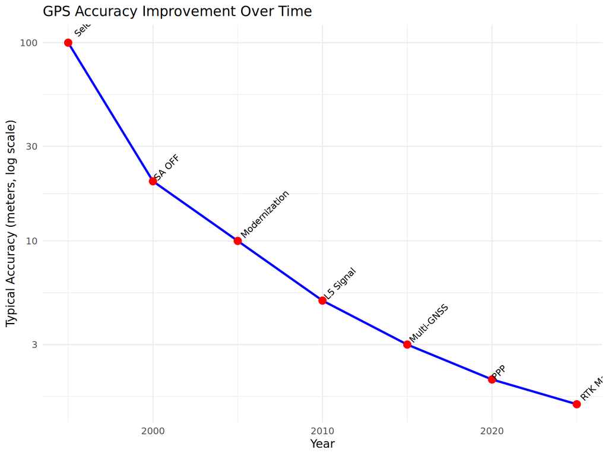

GNSS Accuracy Evolution

## 6.4 Cosmic Radio Sources

#### 6.4.0.1 Natural Radio Emissions

**Sources:**

1. **Sun**: Solar radio bursts
2. **Jupiter**: Decametric emissions
3. **Pulsars**: Rotating neutron stars
4. **Quasars**: Active galactic nuclei
5. **CMB**: Cosmic Microwave Background (2.725 K)

**Cosmic Microwave Background:**

- Relic radiation from Big Bang
- Peak at ~160 GHz (1.9 mm)
- Temperature: 2.725 K
- Blackbody spectrum

**Fast Radio Bursts (FRBs):**

- Millisecond-duration pulses
- Extragalactic origin
- Extreme energies
- Mystery: what creates them?

#### 6.4.0.2 Radio Frequency Interference (RFI)

**Challenge for Radio Astronomy:**

- Terrestrial transmitters
- Satellite downlinks
- Unintentional emissions
- Power line noise

**Mitigation:**

- Radio quiet zones
- Spectral filtering
- RFI excision algorithms
- Space-based observatories

## 6.5 Future of RF Technology

#### 6.5.0.1 Spacetime and Cosmic Perspective

**What is Spacetime?**

Spacetime is a four-dimensional geometric structure that unifies:

- 3 dimensions of space (x, y, z)
- 1 dimension of time (t)

Into a single mathematical object where all physical events occur.

**Quantifying Spacetime:**

**Special Relativity (flat spacetime):**

$$ds^2 = -c^2 dt^2 + dx^2 + dy^2 +
dz^2$$

**General Relativity (curved spacetime):**

- Uses metric tensor $g_{\mu\nu}$
- Curvature described by Einstein field equations
- Mass-energy tells spacetime how to curve
- Spacetime curvature tells matter how to move

**Universal Representation:**

Yes - all known physical phenomena occur in spacetime. However:

- At Planck scale (~10⁻³⁵ m), spacetime may break down
- Quantum gravity may reveal deeper structure

#### 6.5.0.2 Temperature in RF and Physics

**What is Temperature? (Precise Definition)**

Temperature is the **average energy per degree of freedom** in a system.

**Not a force** - it’s a statistical measure of random kinetic energy.

**At different scales:**

| Scale | Temperature Manifestation |
| --- | --- |
| Atomic | Random atomic motion, vibrations |
| Molecular | Phonons (lattice vibrations) |
| Electronic | Electron excitations, thermal noise |
| Cosmic | Radiation fields, nuclear reactions |

**Temperature and RF:**

1. **Thermal Noise (Johnson-Nyquist Noise)**:
   $$P_n = kTB$$
   where k = Boltzmann constant, T = temperature, B = bandwidth
2. **Noise Figure**: Degradation of SNR
3. **Phase Noise**: Temperature-dependent oscillator jitter
4. **Cosmic Microwave Background**: 2.725 K blackbody radiation

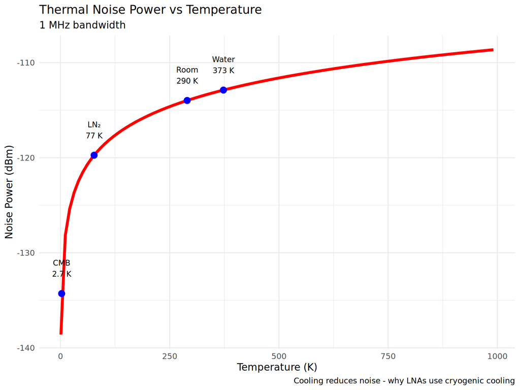

Thermal Noise Power vs Temperature

#### 6.5.0.3 The Unifying Thread: Atomic to Cosmic

**Everything Connects Through:**

1. **Quantum Fields**: Reality at the deepest level
2. **Symmetry Principles**: Conservation laws
3. **Scale Separation**: Different forces dominate at different scales
4. **Electromagnetic Field**: Unifies RF from atomic to cosmic

**The Complete Picture:**

```
Quantum Fields
    ↓
Elementary Particles (electrons, quarks)
    ↓
Atoms (EM + Pauli exclusion)
    ↓
Molecules (electron sharing)
    ↓
Condensed Matter (bands, phonons)
    ↓
Devices (transistors, antennas)
    ↓
Systems (transmitters, receivers)
    ↓
Networks (cellular, satellite)
    ↓
Cosmic (space communications, radio astronomy)
```

**One Unifying Statement:**

Matter, chemistry, electronics, and cosmic structure all emerge from a small set of quantum fields obeying symmetry constraints, with the Pauli exclusion principle enforcing structure, electromagnetism enabling interaction, and relativity binding electricity and magnetism into a single field that transports energy across all scales from atomic to cosmic.

#### 6.5.0.4 Emerging Technologies

**Terahertz (THz):**

- 0.1 - 10 THz
- Between RF and optical
- Applications: imaging, spectroscopy, 6G

**Quantum Communications:**

- Quantum key distribution
- Quantum radar
- Entanglement-based

**Reconfigurable Intelligent Surfaces (RIS):**

- Smart reflecting surfaces
- Control propagation environment
- Passive beamforming

#### 6.5.0.5 6G Vision (2030+)

**Goals:**

- Terabit/s data rates
- Sub-millisecond latency
- AI-native networks
- Holographic communications
- Integration with sensing

**Technologies:**

- THz frequencies (100-300 GHz)
- Massive MIMO evolution
- Satellite-terrestrial integration
- Quantum-safe security

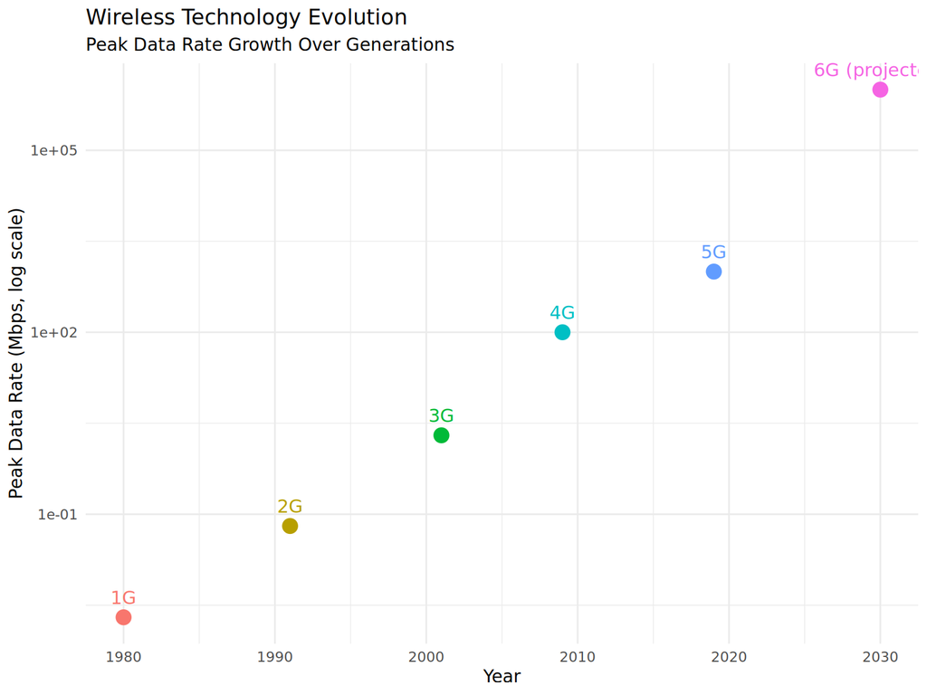

Wireless Technology Evolution

# 7 About

### 7.0.1 About These Notes

#### 7.0.1.1 Purpose

These teaching notes provide a comprehensive journey through RF engineering concepts, organized from the smallest scales (atomic/quantum) to the largest (cosmic/space). This structure helps students understand:

1. How fundamental physics principles scale up to practical applications
2. The interconnections between different areas of RF engineering
3. Real-world applications at each scale

#### 7.0.1.2 How to Use These Notes

**Navigation:** - Use the tabs at the top to jump between different scale levels - Each tab contains multiple subsections accessible via the internal tabs - All sections include theoretical explanations, visualizations, and practical examples

**Interactive Elements:** - Graphs and charts are generated dynamically - Equations are rendered using LaTeX - Code examples demonstrate RF calculations

#### 7.0.1.3 Topics Covered

1. **Atomic & Quantum Level**: Fundamental RF physics
2. **Molecular & Material Level**: RF materials and substrates
3. **Device Level**: Components, circuits, and antennas
4. **System Level**: Complete RF systems and communications
5. **Terrestrial Level**: Networks and infrastructure
6. **Cosmic Level**: Space communications and radio astronomy

#### 7.0.1.4 Author Information

These notes are designed for RF engineering students and professionals seeking a comprehensive understanding of the field. The material progresses from fundamental theory to practical applications.

#### 7.0.1.5 Technical Requirements

**To render these notes:**

- R (version ≥ 4.0)
- RStudio (recommended)
- Required R packages:
  - flexdashboard
  - knitr
  - ggplot2

**To compile:**

```r
rmarkdown::render("RF_Teaching_Notes.Rmd")
```

#### 7.0.1.6 References

Key textbooks and resources used:

- Pozar, D. M. (2011). *Microwave Engineering*
- Balanis, C. A. (2016). *Antenna Theory: Analysis and Design*
- Rappaport, T. S. (2002). *Wireless Communications: Principles and Practice*
- IEEE Transactions on Microwave Theory and Techniques
- Various ITU and 3GPP technical specifications

#### 7.0.1.7 License

These educational materials are provided for teaching and learning purposes.

#### 7.0.1.8 Version

Version 1.0 - 2026

**Feedback Welcome:** Suggestions for improvements or additional topics are welcome!